# Monte Carlo Methods with Application in Fincance

Zhang Xinran

## 2.1 Control Variates Method

### Goal

To estimate E[X]

### Method

n samples {Xi} and n control variate samples {Yi}, with E(Y)= µ_bar.  
The estimate is then *v_est = mean(X)-b*(mean(Y)-µ_bar)*, where b is a fixed constant.  
The variance of estimate is reduced with a good choice of b.

### Optimal choice of b

the one that minimizes the variance of v_est.  
b_optimal_est = sum((Xi-mean(X))(Yi-mean(Y)))/sum((Yi-mean(Y))^2)

### Example 2.1

Use underlying stock price as *control variates* to estimate the price of a call option with maturaty T and strike price K.

```r
S0 = 50
r = 0.05
sigma = 0.2
T = 1
n = 10000

K1 = 45
K2 = 55
K3 = 75
K4 = 85
K = c(K1,K2,K3,K4)
```

##### plain Monte Carlo Methods

```r
set.seed(36)
Z = rnorm(n)
S = S0*exp((r-sigma^2/2)*T+sigma*sqrt(T)*Z)
X = rep(0,n)
v = vector()
se = vector()
for (k in 1:4){
  for (i in 1:n){
    X[i] = exp(-r*T)*max(S[i]-K[k], 0)
  }

  v[k] = mean(X)
  se[k] = sqrt(var(X)/n)
}
v
```

```
## [1] 8.32480240 3.02580309 0.18234584 0.03890458
```

```r
se
```

```
## [1] 0.08733568 0.05849617 0.01468357 0.00671918
```

##### control variate method and b = 1

```r
v1 = vector()
se1 = vector()
for (k in 1:4){
  for (i in 1:n){
    X[i] = exp(-r*T)*max(S[i]-K[k], 0)
  }
  Y = exp(-r*T)*S-S0
  b1 = 1
  H1 = X-b1*Y
  v1[k] = mean(H1)
  se1[k] = sqrt((sum(H1^2)-n*v1[k]^2)/(n*(n-1)))
}
v1
```

```
## [1] 8.3755862 3.0765869 0.2331297 0.0896884
```

```r
se1
```

```
## [1] 0.02727634 0.06042678 0.09661969 0.10025936
```

##### control variate method and b = b*

```r
v2 = vector()
se2 = vector()
for (k in 1:4){
  for (i in 1:n){
    X[i] = exp(-r*T)*max(S[i]-K[k], 0)
  }
  Y = exp(-r*T)*S-S0
  b2 = sum((X-mean(X))*(Y-mean(Y)))/sum((Y-mean(Y))^2)
  H2 = X-b2*Y
  v2[k] = mean(H2)
  se2[k] = sqrt((sum(H2^2)-n*v2[k]^2)/(n*(n-1)))
  print(cor(X,Y))
}
```

```
## [1] 0.9696859
## [1] 0.849776
## [1] 0.4079579
## [1] 0.2423192
```

```r
v2
```

```
## [1] 8.36710162 3.05063107 0.18533781 0.03971781
```

```r
se2
```

```
## [1] 0.021340885 0.030835907 0.013406111 0.006518925
```

##### Comparison of the result

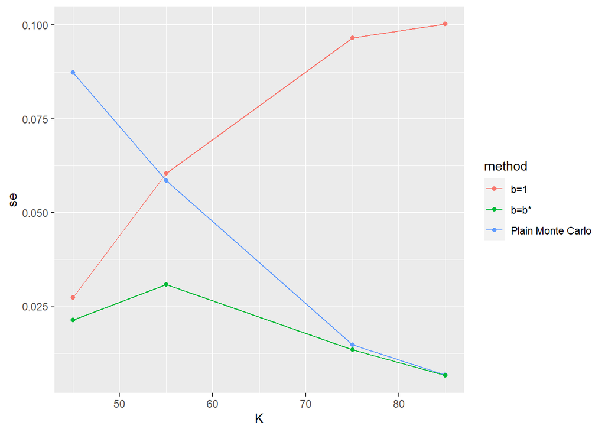

```r
library(ggplot2)
result = data.frame(rep(K,3))
colnames(result)='K'
result$method = c(rep('Plain Monte Carlo',4),rep('b=1',4),rep('b=b*',4))
result$est = c(v,v1,v2)
result$se = c(se,se1,se2)

ggplot(result, aes(x=K, y=se, group=method, color=method))+
  geom_line()+geom_point()
```

##### Findings

We can see that Control Variate Method with b = b* gives best result, and there is a significant reduction in standard error compared to plain Monte Carlo Method for K = 45, 55.

### Example 2.2

Use analytically tractable derivatives as control variate to estimate the price of a discretely monitored average price call option.

```r
r = 0.05
T = 1
sigma = 0.2
m = 12
S0 = 50
n = 10000
t = rep(0,m)
for (i in 1:m){
  t[i]=i*T/m
}
S = rep(0,m)
X = rep(0,n)
K1 = 45
K2 = 55
K3 = 65
K4 = 75
K = c(K1,K2,K3,K4)
```

##### plain Monte Carlo Method

```r
v = vector()
se = vector()
for (j in 1:4){
  set.seed(29)
  for (i in 1:n){
    for (k in 1:m){
      Z = rnorm(1)
      if (k==1) {
        S[k]=S0*exp((r-0.5*sigma^2)*(t[k])+
                      sigma*sqrt(t[k])*Z)
       } else {
         S[k]=S[k-1]*exp((r-0.5*sigma^2)*(t[k]-t[k-1])+sigma*sqrt(t[k]-t[k-1])*Z)
       }
    }
    ari_mean = mean(S)
    X[i] = exp(-r*T)*max(ari_mean-K[j], 0)
  }
  v[j] = mean(X)
  se[j] = sqrt(var(X)/n)
}
v
```

```
## [1] 6.519150216 1.149908995 0.081430118 0.002572701
```

```r
se
```

```
## [1] 0.054598688 0.027112277 0.006803979 0.001172631
```

##### Control variates method with b=1

```r
b = 1
geo_mean = rep(0,n)
v1 = rep(0,4)
se1 = rep(0,4)
for (j in 1:4){
  for (i in 1:n){
    for (k in 1:m){
      Z = rnorm(1)
      if (k==1) {
        S[k]=S0*exp((r-0.5*sigma^2)*(t[k])+
                      sigma*sqrt(t[k])*Z)
      } else {
        S[k]=S[k-1]*exp((r-0.5*sigma^2)*(t[k]-t[k-1])+sigma*sqrt(t[k]-t[k-1])*Z)
      }
    }
    ari_mean = mean(S)
    geo_mean[i] = exp(mean(log(S)))
    X[i] = exp(-r*T)*max(ari_mean-K[j], 0)
  }

  Y = rep(0,n)
  for (i in 1:n){
    Y[i] = exp(-r*T)*max(geo_mean[i]-K[j], 0)
  }
  p = mean(Y)
  H = X-b*(Y-p)
  v1[j] = mean(H)
  se1[j] = sqrt((sum(H^2)-n*v1[j]^2)/(n*(n-1)))

}
v1
```

```
## [1] 6.392209278 1.155572759 0.077270982 0.005582905
```

```r
se1
```

```
## [1] 0.0017338990 0.0016945220 0.0011131945 0.0005748776
```

##### Control variates method with b=b*

```r
geo_mean = rep(0,n)
v2 = vector()
se2 = vector()
for (j in 1:4){
  for (i in 1:n){
    for (k in 1:m){
      Z = rnorm(1)
      if (k==1) {
        S[k]=S0*exp((r-0.5*sigma^2)*(t[k])+
                      sigma*sqrt(t[k])*Z)
      } else {
        S[k]=S[k-1]*exp((r-0.5*sigma^2)*(t[k]-t[k-1])+sigma*sqrt(t[k]-t[k-1])*Z)
      }
    }
    ari_mean = mean(S)
    geo_mean[i] = exp(mean(log(S)))
    X[i] = exp(-r*T)*max(ari_mean-K[j], 0)
  }

  Y = rep(0,n)
  for (i in 1:n){
    Y[i] = exp(-r*T)*max(geo_mean[i]-K[j], 0)
  }

  p = mean(Y)
  b = sum((X-mean(X))*(Y-mean(Y)))/sum((Y-mean(Y))^2)
  b
  H = X-b*(Y-p)
  v2[j] = mean(H)
  se2[j] = sqrt((sum(H^2)-n*v2[j]^2)/(n*(n-1)))
}
v2
```

```
## [1] 6.451687165 1.097707501 0.084079194 0.002783167
```

```r
se2
```

```
## [1] 0.0013048203 0.0010480677 0.0007306958 0.0001826628
```

##### Comparison of the result

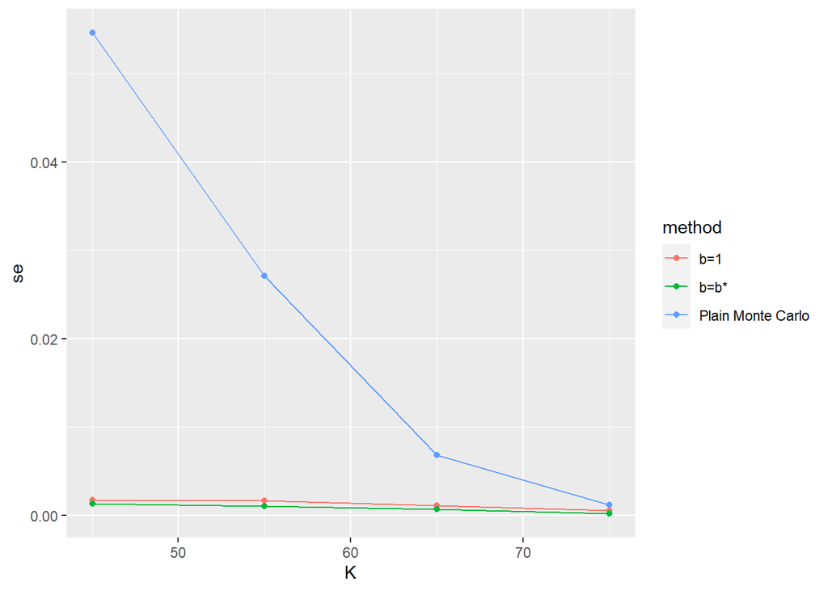

```r
library(ggplot2)

result = data.frame(rep(K,3))
colnames(result)='K'
result$method = c(rep('Plain Monte Carlo',4),rep('b=1',4),rep('b=b*',4))
result$est = c(v,v1,v2)
result$se = c(se,se1,se2)

ggplot(result, aes(x=K, y=se, group=method, color=method))+
  geom_line()+geom_point()
```

##### Findings

The variance deduction is very significant for both choices of b.

### Example 2.3

Estimate the price of a butterfly spread option Control Variate Method: use underlying stock price as the control variate

```r
r = 0.05
n = 400000
sigma = 0.2
S0 = 50
K1 = 45
K2 = 50
K3 = 55

T = c(1, 0.5, 0.25) # 1, 0.5, 0.25
```

##### Plain Monte Carlo Methods

```r
set.seed(29)
Z = rnorm(n)

X = rep(0,n)
v = vector()
se = vector()
for (t in 1:3){
  S = S0*exp((r-0.5*sigma^2)*T[t]+sigma*sqrt(T[t])*Z)
  for(i in 1:n){
    X[i] = exp(-r*T[t])*(max(S[i]-K1,0) + max(S[i]-K3,0) - 2*max(S[i]-K2,0))
  }
  v[t] = mean(X)
  se[t] = sqrt(var(X)/n)
}
v
```

```
## [1] 0.9188987 1.3132152 1.8147659
```

```r
se
```

```
## [1] 0.002287234 0.002556698 0.002678369
```

##### Control Variate Methods with b = b*

```r
v1 = vector()
se1 = vector()
b = vector()
beta = vector()
for (t in 1:3){
  S = S0*exp((r-0.5*sigma^2)*T[t]+sigma*sqrt(T[t])*Z)
  for(i in 1:n){
    X[i] = exp(-r*T[t])*(max(S[i]-K1,0) + max(S[i]-K3,0) - 2*max(S[i]-K2,0))
  }
  Y = exp(-r*T[t])*S  # Control Variate
  b[t] = sum((X-mean(X))*(Y-mean(Y)))/sum((Y-mean(Y))^2)
  beta[t] = b[t]*(sqrt(var(Y)))/(sqrt(var(X)))
  H = X-b[t]*(Y-S0)
  v1[t] = mean(H)
  se1[t] = sqrt((sum(H^2)-n*v1[t]^2)/(n*(n-1)))
}
b
```

```
## [1] -0.02201312 -0.03218592 -0.04464772
```

```r
beta
```

```
## [1] -0.1537135 -0.1414680 -0.1321356
```

```r
v1
```

```
## [1] 0.9187353 1.3130433 1.8145951
```

```r
se1
```

```
## [1] 0.002260051 0.002530985 0.002654884
```

##### Comparison of the result

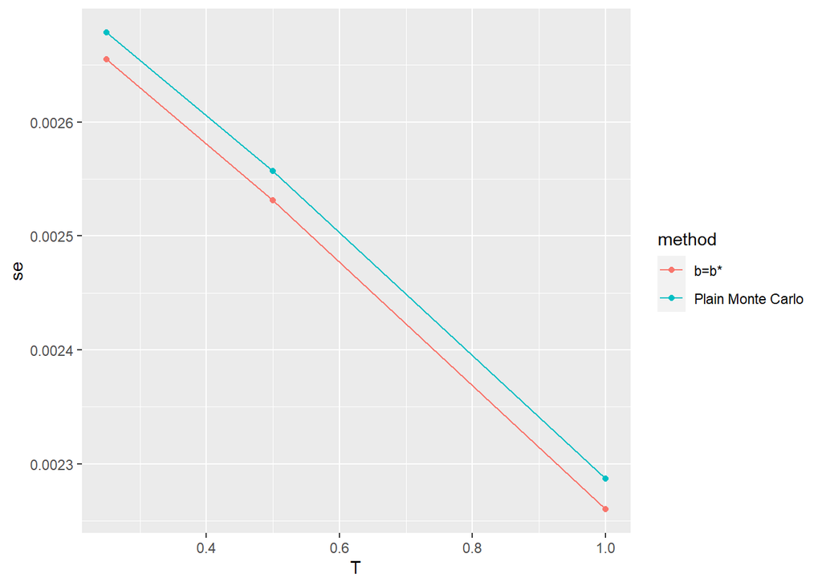

```r
result = data.frame(rep(T,2))
colnames(result)='T'
result$method = c(rep('Plain Monte Carlo',3),rep('b=b*',3))
result$est = c(v,v1)
result$se = c(se,se1)
library(ggplot2)
ggplot(result, aes(x=T, y=se, group=method, color=method))+
  geom_line()+geom_point()
```

### Example 2.4

Control Variate Method with underlying stock price as control vaiate, to estimate the straddle price

##### Plain Monte Carlo

```r
n = 10000
T = 1
K = c(60,70,80,90)
sigma = 0.2
r = 0.02
S0 = 50
Z = rnorm(n)
S = S0*exp((r-0.5*sigma^2)*T+sigma*sqrt(T)*Z)
X = rep(0,n)
v = vector()
se = vector()
for (k in 1:4){
  for (i in 1:n){
    X[i] = exp(-r*T)*(max(S[i]-K[k], 0) + max(K[k]-S[i],0))
  }

  v[k] = mean(X)
  se[k] = sqrt(var(X)/n)
}
v
```

```
## [1] 11.39343 19.16646 28.49067 38.19577
```

```r
se
```

```
## [1] 0.07031842 0.08936876 0.09778715 0.10035035
```

##### Control Variate Methods

```r
v1 = vector()
se1 = vector()
b = vector()
for (k in 1:4){
  for (i in 1:n){
    X[i] = exp(-r*T)*(max(S[i]-K[k], 0) + max(K[k]-S[i],0))
  }
  Y = exp(-r*T)*S-S0
  b[k] = sum((X-mean(X))*(Y-mean(Y)))/sum((Y-mean(Y))^2)
  H = X-b[k]*Y
  v1[k] = mean(H)
  se1[k] = sqrt((sum(H^2)-n*v1[k]^2)/(n*(n-1)))
}
b
```

```
## [1] -0.4374270 -0.8217993 -0.9540853 -0.9897637
```

```r
v1
```

```
## [1] 11.41277 19.20280 28.53285 38.23953
```

```r
se1
```

```
## [1] 0.054640018 0.032739050 0.015556677 0.006306379
```

##### Comparison of the result

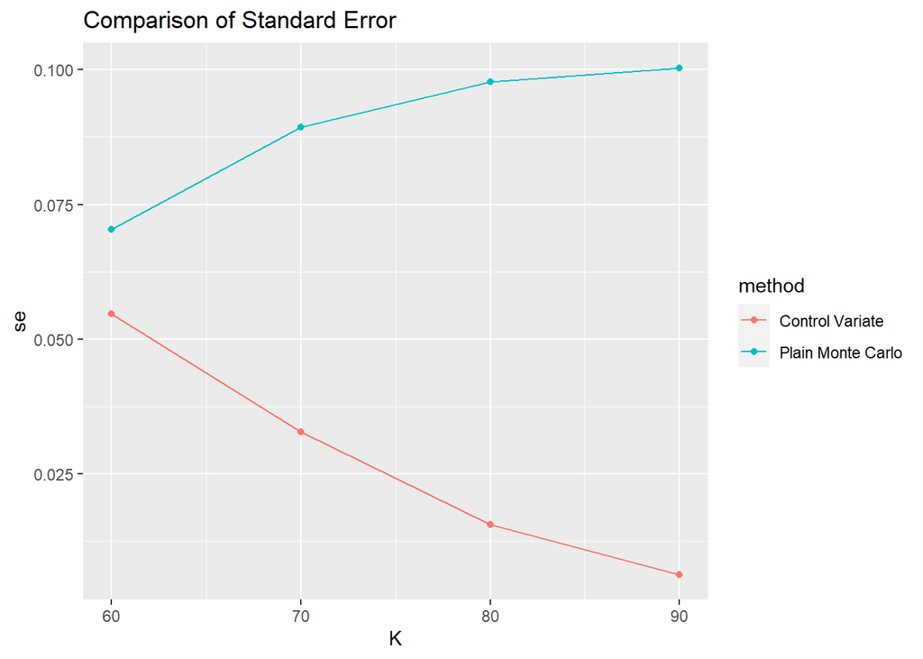

```r
result = data.frame(rep(K,2))
colnames(result)='K'
result$method = c(rep('Plain Monte Carlo',4),rep('Control Variate',4))
result$est = c(v,v1)
result$se = c(se,se1)

ggplot(result, aes(x=K, y=se, group=method, color=method))+
  geom_line()+geom_point()+ggtitle("Comparison of Standard Error")
```

## Example 2.5

To estimate a discretely monitored lookback call option with fixed strike price K and maturity T

```r
S0 = 50
r = 0.05
sigma = 0.2
K = 65
T = 1
m =50
n = 10000
t = rep(0,m)
for (i in 1:m){
  t[i]=i*T/m
}
```

##### plain Monte Carlo Method

```r
S = rep(0,m)
X = rep(0,n)
set.seed(29)
for (i in 1:n){
  for (k in 1:m){
    Z = rnorm(1)
    if (k==1) {
      S[k]=S0*exp((r-0.5*sigma^2)*(t[k])+sigma*sqrt(t[k])*Z)
    } else {
      S[k]=S[k-1]*exp((r-0.5*sigma^2)*(t[k]-t[k-1])+sigma*sqrt(t[k]-t[k-1])*Z)
    }
  }
  max_S = max(S)
  X[i] = exp(-r*T)*max(max_S-K, 0)
}
mean(X)
```

```
## [1] 1.307344
```

```r
se = sqrt(var(X)/n)
se
```

```
## [1] 0.0378302
```

##### (i) use underlying stock price as control variate

```r
Z = rnorm(n)
S = S0*exp((r-0.5*sigma^2)*T+sigma*sqrt(T)*Z)

Y = exp(-r*T)*S-S0
b = sum((X-mean(X))*(Y-mean(Y)))/sum((Y-mean(Y))^2)
b   # b very small -> 0, almost no reduction in variance
```

```
## [1] 0.003830713
```

```r
H = X-b*Y
v = mean(H)
v
```

```
## [1] 1.307267
```

```r
se2 = sqrt((sum(H^2)-n*v^2)/(n*(n-1)))
se2
```

```
## [1] 0.03782822
```

##### (ii) use call option with strike price K and maturity T

```r
Z = rnorm(n)
S = S0*exp((r-sigma^2/2)*T+sigma*sqrt(T)*Z)
Y = rep(0,n)
for(i in 1:n){
  Y[i] = exp(-r*T)*max(S[i]-K,0)
}
b = sum((X-mean(X))*(Y-mean(Y)))/sum((Y-mean(Y))^2)
b    # b also very small
```

```
## [1] 0.01284282
```

```r
H = X-b*(Y-S0)
v = mean(H)
v
```

```
## [1] 1.939037
```

```r
se2 = sqrt((sum(H^2)-n*v^2)/(n*(n-1)))
se2
```

```
## [1] 0.03782825
```

##### (iii) use geometric mean as control variate

```r
S0 = 50
r = 0.05
sigma = 0.2
K = 55
T = 1
m =50
n = 10000
t = rep(0,m)
for (i in 1:m){
  t[i]=i*T/m
}

geo_mean = rep(0,n)
X = rep(0,n)
S = rep(0,m)
set.seed(29)

for (i in 1:n){
  for (k in 1:m){
    Z = rnorm(1)
    if (k==1) {
      S[k]=S0*exp((r-0.5*sigma^2)*(t[k])+sigma*sqrt(t[k])*Z)
    } else {
      S[k]=S[k-1]*exp((r-0.5*sigma^2)*(t[k]-t[k-1])+sigma*sqrt(t[k]-t[k-1])*Z)
    }
  }
  max_S = max(S)
  X[i] = exp(-r*T)*max(max_S-K, 0)
  geo_mean[i] = exp(mean(log(S)))
}

Y = rep(0,n)
for (i in 1:n){
  Y[i] = exp(-r*T)*max(geo_mean[i]-K, 0)
}

#Y[1:100]
p = mean(Y)
b = sum((X-mean(X))*(Y-mean(Y)))/sum((Y-mean(Y))^2)
b
```

```
## [1] 2.375108
```

```r
H = X-b*(Y-p)
v = mean(H)
v
```

```
## [1] 4.967245
```

```r
se = sqrt((sum(H^2)-n*v^2)/(n*(n-1)))
se
```

```
## [1] 0.0357381
```

## 3 Importance Sampling

### Goal

estimate the expected value µ= E[h(X)], X ~ f(x)

### Method

µ = Eg[h(Y)*f(Y)/g(Y)], where Y~g, and g is the *alternative density*. In order to preserve th unbiasness, h(Yi) is weighted by the likelihood ratio f(Yi)/g(Yi).

### Guidelines for selecting g

If g(x) = ch(x)f(x) for some constant c, then the IS estimate has 0 variance.

#### Mode Matching Method

The mode of g(x) match the mode of h(x)f(x). Take derivative of h(x)f(x) and set it to zero. The equation can be solved numerically by the bisection method.

#### Cross Entropy Method

Try yo solve for fθ(x) that is closest to g*(x) in the sense of *Kullback–Leibler cross entropy or relative entropy*.  
In the event of very small probability, the *general iterative cross entropy algorithm* can be used. The method make use of N pilot sample to run for several iterations to find a suitable tilting parameter θ.

### Example 3.1

Use importance sampling to estimate the price of a binary call option.

```r
S0 = 50
r = 0.01
sigma = 0.1
T = 1
n = 10000

K = c(60,70,80,100)
b = vector()
for (k in 1:4){
  b[k] = (log(K[k]/S0) - (r-sigma^2/2)*T)/(sigma*sqrt(T))
}

# theoretical value
theo = exp(-r*T)*(1-pnorm(b))
theo
```

```
## [1] 3.771743e-02 4.541071e-04 1.642872e-06 2.932382e-12
```

##### Plain Monte Carlo Methods

```r
est = vector()
se = vector()
re = vector()
for (k in 1:4){
  set.seed(29)
  X = exp(-r*T)*(rnorm(n)>=b[k])
  est[k] = mean(X)
  se[k] = sqrt(var(X)/n)
  re[k] = abs((est[k] - theo[k])/theo[k])*100
}
est
```

```
## [1] 0.03742388 0.00019801 0.00000000 0.00000000
```

```r
se
```

```
## [1] 0.0018882407 0.0001400072 0.0000000000 0.0000000000
```

```r
re
```

```
## [1]   0.7782781  56.3957540 100.0000000 100.0000000
```

##### Importance Sampling

```r
est2 = vector()
se2 = vector()
re2 = vector()
for (k in 1:4){
  set.seed(29)
  x = max(b[k],0)
  H = rep(0,n)
  for (i in 1:n){
    Y = rnorm(1, x, 1)
    if (Y<b[k]){
      H[i]=0
    } else{
      H[i] = exp(-r*T-x*Y+x^2/2)
    }
  }
  est2[k] = mean(H)
  se2[k] = sqrt((sum(H^2)-n*est2[k]^2)/(n*(n-1)))
  re2[k] = abs((est2[k]-theo[k])/theo[k])*100
}
est2
```

```
## [1] 3.683763e-02 4.402736e-04 1.585376e-06 2.813697e-12
```

```r
se2
```

```
## [1] 5.426503e-04 8.623179e-06 3.693349e-08 8.057869e-14
```

```r
re2
```

```
## [1] 2.332613 3.046310 3.499734 4.047389
```

##### Comparison of the result

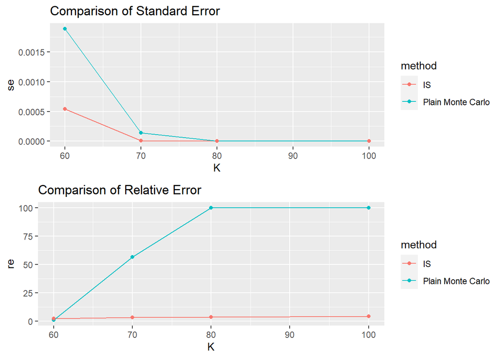

```r
result = data.frame(rep(K,2))
colnames(result)='K'
result$method = c(rep('Plain Monte Carlo',4),rep('IS',4))
result$est = c(est,est2)
result$se = c(se,se2)
result$re = c(re,re2)
library(ggplot2)
p1 = ggplot(result, aes(x=K, y=se, group=method, color=method))+
  geom_line()+geom_point()+ggtitle("Comparison of Standard Error")
p2 = ggplot(result, aes(x=K, y=re, group=method, color=method))+
  geom_line()+geom_point()+ggtitle("Comparison of Relative Error")
require(gridExtra)
grid.arrange(p1,p2)
```

##### Comments

Plain Monte Carlo performs bad when K becomes larger because with a moderate sample size, only a few or even none of the samples will reach the strike price K. IS method produce quite accurate result even when K is large.

### Example 3.2

Use importance sampling to estimate the price of a call option. Use Mode Matching Method to find theta for the alternative distribution.

```r
S0 = 50
r = 0.05
sigma = 0.2
T = 1
n = 10000

K = c(60,80,100,120)
theta = vector()
theo = vector()
# theoretical value by using Black-Scholes formula
for (k in 1:4){
  theta[k] = 1/(sigma*sqrt(T))*log(K[k]/S0)+(sigma/2-r/sigma)*sqrt(T)
  theo[k] = S0*pnorm(sigma*sqrt(T)-theta[k])-K[k]*exp(-r*T)*pnorm(-theta[k])
}
theo
```

```
## [1] 1.623739e+00 7.947713e-02 2.399418e-03 6.066121e-05
```

##### plain Monte Carlo

```r
set.seed(29)
X = rnorm(n)
for (k in 1:4){
  h = S0*exp(-0.5*sigma^2*T+sigma*sqrt(T)*X)-exp(-r*T)*K[k]
  for (i in 1:n){
    h[i] = max(0, h[i])
  }
  est[k] = mean(h)
  se[k] = sqrt(var(h)/n)
}
re = abs((est-theo)/theo*100)
est
```

```
## [1] 1.6487724978 0.0819016085 0.0009784859 0.0000000000
```

```r
se
```

```
## [1] 0.0437456583 0.0090286062 0.0006973721 0.0000000000
```

```r
re
```

```
## [1]   1.541738   3.050539  59.219857 100.000000
```

##### Importance Sampling

```r
# find x* using bisection method
f <- function(x){
  S0*exp(-0.5*sigma^2*T+sigma*sqrt(T)*x)*(sigma*sqrt(T)-x)+exp(-r*T)*K[4]*x
}

#f(4)
#f(5)

x1= vector()
x2 = vector()
x1[1] = 1
x2[1] = 2
x1[2] = 2
x2[2] = 3
x1[3] = 3
x2[3] = 4
x1[4] = 4
x2[4] = 5

for(k in 1:4){
  while (abs(x1[k]-x2[k])>=1e-6){
    x = (x1[k]+x2[k])/2
    if (f(x)==0){
      x1[k] = x
      x2[k] = x
    } else {
      if ((f(x)>0 & f(x1[k])>0)|(f(x)<0 & f(x1[k])<0)){
        x1[k] = x
      } else {
        x2[k] = x
      }
    }
  }
}
x1
```

```
## [1] 1.999999 2.999999 3.999999 4.456904
```

```r
# importance sampling
est1 = vector()
se1 = vector()
set.seed(29)
for (k in 1:4){
  H = rep(0,n)
  Y = rnorm(n,x1[k],1)
  h = S0*exp(-0.5*sigma^2*T+sigma*sqrt(T)*Y)-exp(-r*T)*K[k]
  for (i in 1:n){
    H[i] = max(0, h[i])*exp(-x1[k]*Y[i] + (x1[k])^2/2)
  }
  est1[k] = mean(H)    ## when K is large, this value is very unstable for diff seeds
  se1[k] = sqrt((sum(H^2)-n*est1[k]^2)/(n*(n-1)))
}
est1
```

```
## [1] 1.6136592976 0.0801653106 0.0023923004 0.0000623121
```

```r
se1
```

```
## [1] 1.208184e-02 8.205501e-04 3.090503e-05 8.784147e-07
```

```r
re1 = abs((est1-theo)/theo)*100
re1
```

```
## [1] 0.6207532 0.8658884 0.2966216 2.7214991
```

##### Comparison of the result

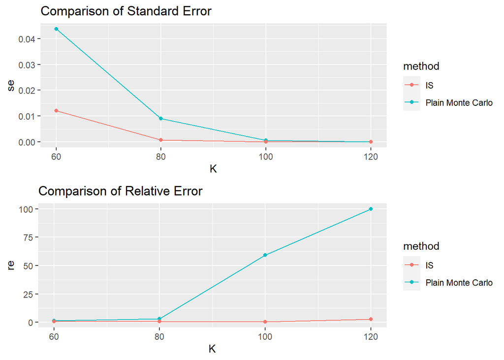

```r
result = data.frame(rep(K,2))
colnames(result)='K'
result$method = c(rep('Plain Monte Carlo',4),rep('IS',4))
result$est = c(est,est1)
result$se = c(se,se1)
result$re = c(re,re1)

p1 = ggplot(result, aes(x=K, y=se, group=method, color=method))+
  geom_line()+geom_point()+ggtitle("Comparison of Standard Error")
p2 = ggplot(result, aes(x=K, y=re, group=method, color=method))+
  geom_line()+geom_point()+ggtitle("Comparison of Relative Error")
require(gridExtra)
grid.arrange(p1,p2)
```

##### Comments Plain Monte Carlo performs bad when K becomes larger. IS method performe much better especially when K is large.

## 3.2 The Cross Entropy Method

### Example 3.3

Estimate the price of a call option, using cross entropy method to find the tilting theta.

```r
S0 = 50
r = 0.05
sigma = 0.2
T = 1
N = 2000
n = 10000

K = c(60,80,100,120)
set.seed(29)

est2 = vector()
se2 = vector()
for (k in 1:2){
  X = rnorm(N)
  h <- function(x){
    max(S0*exp(-0.5*sigma^2*T+sigma*sqrt(T)*x)-exp(-r*T)*K[k], 0)
  }
  hx = rep(0,N)
  for(i in 1:N){
    hx[i] = h(X[i])
  }

  theta_hat = sum(hx*X)/sum(hx)
  H = rep(0,n)
  for(i in 1:n){
    Y = rnorm(1,theta_hat,1)
    H[i] = h(Y)*exp(-theta_hat*Y + theta_hat^2/2)
  }
  est2[k] = mean(H)
  se2[k] = sqrt((sum(H^2)-n*est2[k]^2)/(n*(n-1)))
}
est2 #when K is large, say 100, produce a lot of NaN
se2
re2 = abs((est2-theo)/theo)*100
re2
```

##### Comment

When K is large, say larger than 100, the basic entropy method produces a lot of NaN. It is because in the estimation of theta_hat, almost all h(X) is 0. A modification(iterative scheme) of the basic method is needed.

Using Iterative cross-entropy scheme to resolve the rare event issue in the example

```r
S0 = 50
r = 0.05
sigma = 0.2
T = 1
N = 2000
K = c(60,80,100,120)

theta_hat0 = vector()
for (k in 1:4){
  theta_hat0[k] = 1/(sigma*sqrt(T))*log(K[k]/S0)-r/sigma*sqrt(T)
}

theta_hat0
```

```
## [1] 0.6616078 2.1000181 3.2157359 4.1273437
```

```r
IT_NUM = 5
theta_hat_final = vector()

for (k in 1:4){
  h <- function(x){
    max(S0*exp(-0.5*sigma^2*T+sigma*sqrt(T)*x)-exp(-r*T)*K[k], 0)
  }

  H = rep(0,N)
  theta_hat = rep(0, IT_NUM+1)
  theta_hat[1] = theta_hat0[k]
  set.seed(29)
  for(j in 1:IT_NUM+1){
    Y = rnorm(N,theta_hat[j-1],1)
    for(i in 1:N){
      H[i] = h(Y[i])
    }
    theta_hat[j] = sum(H*exp(-theta_hat[j-1]*Y)*Y)/sum(H*exp(-theta_hat[j-1]*Y))
  }

  theta_hat
  theta_hat_final[k] = theta_hat[IT_NUM+1]
}
theta_hat_final
```

```
## [1] 1.767400 2.858858 3.812672 4.637165
```

```r
H = rep(0,n)
est3 = vector()
se3 = vector()
for (k in 1:4){
  for (i in 0:n){
    Y = rnorm(1, theta_hat_final[k], 1)
    H[i] = h(Y)*exp(-theta_hat_final[k]*Y + theta_hat_final[k]^2/2)
  }
  est3[k] = mean(H)
  se3[k] = sqrt((sum(H^2)-n*est3[k]^2)/(n*(n-1)))
}
est3  # works well even when K is large, like 120\
```

```
## [1] 1.634362e+00 7.882532e-02 2.415401e-03 6.090838e-05
```

```r
se3
```

```
## [1] 1.092837e-02 7.991160e-04 2.993824e-05 8.673279e-07
```

```r
re3 = abs((est3-theo)/theo)*100
re3
```

```
## [1] 0.6542377 0.8201249 0.6661253 0.4074610
```

##### Comparison of the result

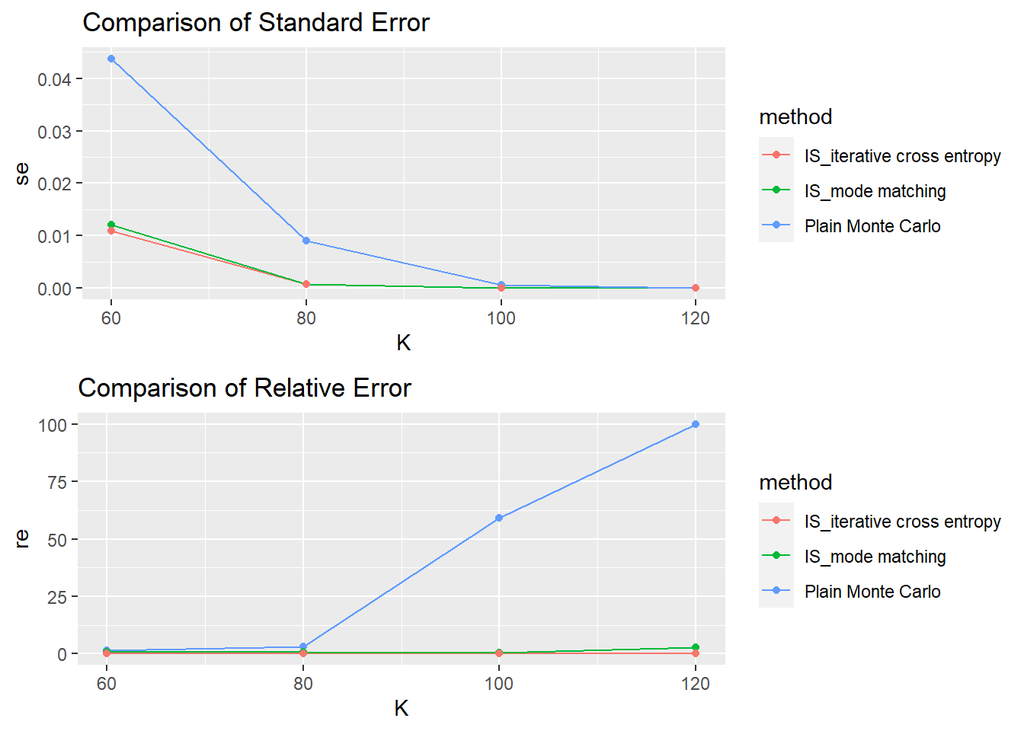

```r
result = data.frame(rep(K,3))
colnames(result)='K'
result$method = c(rep('Plain Monte Carlo',4),rep('IS_mode matching',4),rep('IS_iterative cross entropy',4))
result$est = c(est,est1,est3)
result$se = c(se,se1,se3)
result$re = c(re,re1,se3)
library(ggplot2)
library(gridExtra)
p1 = ggplot(result, aes(x=K, y=se, group=method, color=method))+
  geom_line()+geom_point()+ggtitle("Comparison of Standard Error")
p2 = ggplot(result, aes(x=K, y=re, group=method, color=method))+
  geom_line()+geom_point()+ggtitle("Comparison of Relative Error")
grid.arrange(p1,p2)
```

##### Comment Iterative Cross Entropy Method also works well when K is large.

### Example 3.3(2)

Estimate the call option price, with cross entropy method(same as Example 3.2). Use another method to initialize the tilitng parameter.

```r
rho = 0.1
N = 2000
N0 = 1800
S0 = 50
r = 0.05
sigma = 0.2
T = 1
K = 120
alpha = K
theta_0 = 0
j = 0

F <- function(x){
  S0*exp((r-0.5*sigma^2)*T+sigma*sqrt(T)*x)
}

H <- function(x, alpha){
  exp(-r*T)*max(F(x)-alpha, 0)
}

theta = vector()
theta[1] = theta_0
j=0
H_vector = rep(0,N)

alpha_j = 40
while (alpha_j<alpha){
  j = j+1
  Y = rnorm(N, theta[j],1)
  V = F(Y)
  V = sort(V)
  alpha_j = V[N0]
  for(i in 1:N){
    if ( F(Y[i])>=alpha_j ){
      H_vector[i]=H(Y[i], alpha_j)
    } else {
      H_vector[i]=0
    }
  }
  theta[j+1]= sum(H_vector*exp(-theta[j]*Y)*Y)/sum(H_vector*exp(-theta[j]*Y))
}

theta
```

```
## [1] 0.000000 2.178429 3.932465 5.592191
```

```r
alpha_j
```

```
## [1] 146.6441
```

```r
final_theta = theta[j+1]
H = rep(0,n)
h <- function(x){
  max(S0*exp(-0.5*sigma^2*T+sigma*sqrt(T)*x)-exp(-r*T)*K, 0)
}
for (i in 0:n){
  Y = rnorm(1, final_theta, 1)
  H[i] = h(Y)*exp(-final_theta*Y + final_theta^2/2)
}
est_v = mean(H)
est_v     # works well even when K is large, like 120
```

```
## [1] 6.061405e-05
```

```r
se = sqrt((sum(H^2)-n*est_v^2)/(n*(n-1)))
se
```

```
## [1] 1.249405e-06
```

##### Comment

An alternative way for initializing the parameter for very rare event. In the example, work well when K is large.

### Example 3.4

Iterative cross-entropy method for estimating the price of binary option

```r
S0 = 50
r = 0.01
sigma = 0.1
T = 1
n = 10000
N = 2000
IT_NUM = 5

K = c(60, 70, 80, 100)
b = vector()
theo = vector()
for (k in 1:4){
  b[k] = (log(K[k]/S0) - (r-sigma^2/2)*T)/(sigma*sqrt(T))
}

# theoretical value
theo = exp(-r*T)*(1-pnorm(b))
theo
```

```
## [1] 3.771743e-02 4.541071e-04 1.642872e-06 2.932382e-12
```

##### Plain Monte Carlo Methods (Same as Example 3.1)

```r
est = vector()
se = vector()
re = vector()
for (k in 1:4){
  set.seed(29)
  X = exp(-r*T)*(rnorm(n)>=b[k])
  est[k] = mean(X)
  se[k] = sqrt(var(X)/n)
  re[k] = abs((est[k] - theo[k])/theo[k])*100
}
est
```

```
## [1] 0.03742388 0.00019801 0.00000000 0.00000000
```

```r
se
```

```
## [1] 0.0018882407 0.0001400072 0.0000000000 0.0000000000
```

```r
re
```

```
## [1]   0.7782781  56.3957540 100.0000000 100.0000000
```

```r
# initialize theta_hat0 so that exp(-rT)*E[I{Y>=b}]=0
theta_hat_final = vector()
for (k in 1:4){
  theta_hat0 = b[k]
  H = rep(0,N)
  theta_hat = rep(0, IT_NUM+1)
  theta_hat[1] = theta_hat0

  set.seed(29)
  h <- function(X){
    exp(-r*T)*(X>=b[k])
  }
  for(j in 1:IT_NUM+1){
    Y = rnorm(N,theta_hat[j-1],1)
    for(i in 1:N){
      H[i] = h(Y[i])
    }
    theta_hat[j] = sum(H*exp(-theta_hat[j-1]*Y)*Y)/sum(H*exp(-theta_hat[j-1]*Y))
  }
  theta_hat_final[k] = theta_hat[IT_NUM+1]
}
theta_hat_final
```

```
## [1] 2.159175 3.572339 4.840908 7.011703
```

```r
H = rep(0,n)
for (k in 1:4){
  for (i in 0:n){
    Y = rnorm(1, theta_hat_final[k], 1)
    H[i] = h(Y)*exp(-theta_hat_final[k]*Y + theta_hat_final[k]^2/2)
  }
  est1[k] = mean(H)
  se1[k] = sqrt((sum(H^2)-n*est1[k]^2)/(n*(n-1)))
}
est1
```

```
## [1] 3.757842e-02 4.347055e-04 1.696019e-06 2.907345e-12
```

```r
se1
```

```
## [1] 5.352283e-04 8.549381e-06 3.812227e-08 8.224700e-14
```

```r
re1 = abs((est1 - theo)/theo)*100
re1
```

```
## [1] 0.3685635 4.2724653 3.2350169 0.8538289
```

##### Comparison of the result

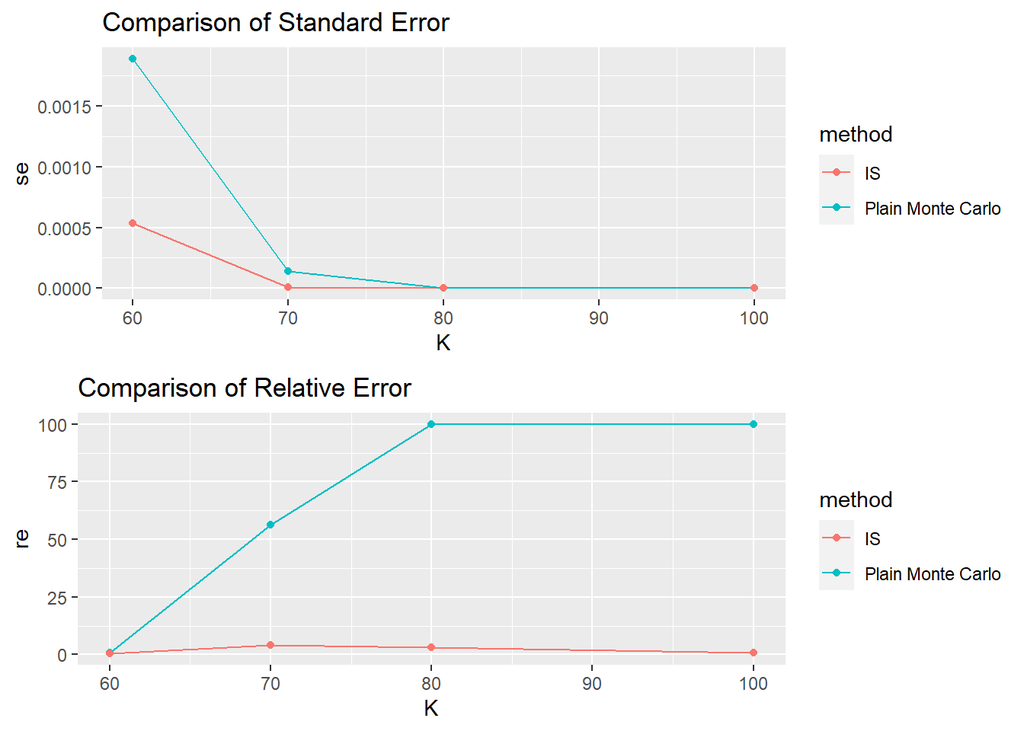

```r
result = data.frame(rep(K,2))
colnames(result)='K'
result$method = c(rep('Plain Monte Carlo',4),rep('IS',4))
result$est = c(est,est1)
result$se = c(se,se1)
result$re = c(re,re1)

p1 = ggplot(result, aes(x=K, y=se, group=method, color=method))+
  geom_line()+geom_point()+ggtitle("Comparison of Standard Error")
p2 = ggplot(result, aes(x=K, y=re, group=method, color=method))+
  geom_line()+geom_point()+ggtitle("Comparison of Relative Error")
grid.arrange(p1,p2)
```

### Exercise 3.A

estimate P(X>=b) with Importance Sampling #### (a) X~Bin(m,p), b = m*a, p<a<1; g(x)~bin(m,a) Comment: the theoretical value seems to be too small for comparing. Also, relative errors are quite large for both methods

```r
plain_est=vector()
plain_se=vector()
plain_re=vector()
IS_est = vector()
IS_se = vector()
IS_re = vector()
m_vec = c(10,20,30)
theo = vector()
for (k in 1:length(m_vec)){
  p = 0.5
  a = 0.9
  m = m_vec[k] #10,100,1000
  n = 10000
  b = m*a
  theo[k] = 1-pbinom(b,m,p)
  ##### Plain Monte Carlo Methods #####
  set.seed(18)
  X = rbinom(n,m,p)
  count = vector()
  for (i in 1:n){
    if (X[i]>=b){
      count[i] = 1
    } else {
      count[i] = 0
    }
  }
  plain_est[k] = mean(count)
  plain_se[k] = sqrt(var(count)/n)
  plain_re[k] = abs((plain_est[k]-theo[k])/theo[k])*100

  ##### Importance Sampling #####
  Y = rbinom(n,m,a)
  count2 = vector()
  for (i in 1:n){
    if (Y[i]>=b){
      count2[i]=1*0.5^m/(a^Y[i]*(1-a)^(m-Y[i]))
    } else{
      count2[i]=0
    }
  }

  IS_est[k] = mean(count2)
  IS_se[k] = sqrt((sum(count2^2)-n*IS_est[k]^2)/(n*(n-1)))
  IS_re[k] = abs((IS_est[k]-theo[k])/theo[k])*100
}

theo
```

```
## [1] 9.765625e-04 2.002716e-05 4.339963e-07
```

```r
plain_est
```

```
## [1] 0.0092 0.0002 0.0000
```

```r
IS_est
```

```
## [1] 1.075770e-02 1.996904e-04 4.214259e-06
```

##### Comparing the result

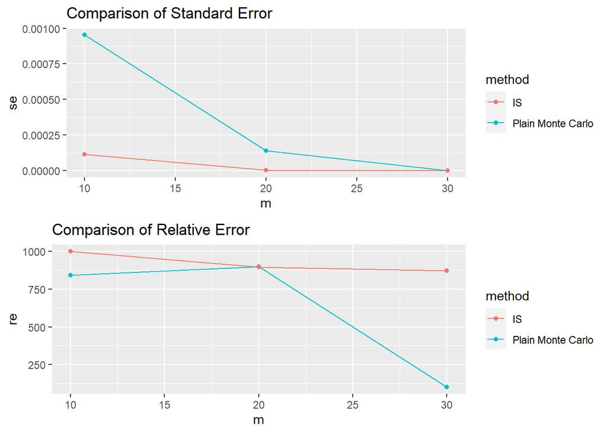

```r
result = data.frame(rep(m_vec,2))
colnames(result)='m'
result$method = c(rep('Plain Monte Carlo',3),rep('IS',3))
result$est = c(plain_est,IS_est)
result$se = c(plain_se,IS_se)
result$re = c(plain_re,IS_re)
library(ggplot2)
library(gridExtra)
p1 = ggplot(result, aes(x=m, y=se, group=method, color=method))+
  geom_line()+geom_point()+ggtitle("Comparison of Standard Error")
p2 = ggplot(result, aes(x=m, y=re, group=method, color=method))+
  geom_line()+geom_point()+ggtitle("Comparison of Relative Error")
grid.arrange(p1,p2)
```

#### (b) X~exp(lambda),b=a/lambda, alternative distribution~exp(1/b)

```r
plain_est=vector()
plain_se=vector()
plain_re=vector()
IS_est = vector()
IS_se = vector()
IS_re = vector()
a_vec = c(2,5,10,20,30)
theo = vector()

for (k in 1:length(a_vec)){
  lambda = 1
  a = a_vec[k] #2,5,10
  n = 10000
  b = a/lambda

  theo[k] = 1-pexp(b,lambda)

  ##### Plain Monte Carlo Methods #####
  set.seed(29)
  X = rexp(n,lambda)
  count = vector()
  for (i in 1:n){
    if (X[i]>=b){
      count[i] = 1
    } else {
      count[i] = 0
    }
  }
  plain_est[k] = mean(count)
  plain_se[k] = sqrt(var(count)/n)
  plain_re[k] = abs((plain_est[k]-theo[k])/theo[k])*100

  ##### Importance Sampling #####
  Y = rexp(n,1/b)
  H = rep(0,n)
  for (i in 1:n){
    if (Y[i]>=b){
      H[i]=1*lambda*b*exp(-lambda*Y[i]+1/b*Y[i])
    } else{
      H[i]=0
    }
  }

  IS_est[k] = mean(H)
  IS_se[k] = sqrt((sum(H^2)-n*IS_est[k]^2)/(n*(n-1)))
  IS_re[k] = abs((IS_est[k]-theo[k])/theo[k])*100
}
```

##### Comparing the result

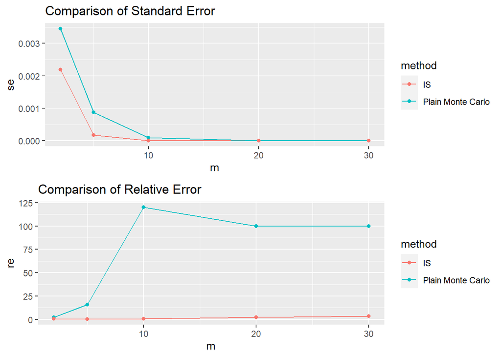

```r
result = data.frame(rep(a_vec,2))
colnames(result)='m'
result$method = c(rep('Plain Monte Carlo',5),rep('IS',5))
result$est = c(plain_est,IS_est)
result$se = c(plain_se,IS_se)
result$re = c(plain_re,IS_re)

p1 = ggplot(result, aes(x=m, y=se, group=method, color=method))+
  geom_line()+geom_point()+ggtitle("Comparison of Standard Error")
p2 = ggplot(result, aes(x=m, y=re, group=method, color=method))+
  geom_line()+geom_point()+ggtitle("Comparison of Relative Error")
grid.arrange(p1,p2)
```

### Exercise 3.B estimate P(X>=b)

##### Plain Monte Carlo Methods

```r
n = 10000
set.seed(29)
X = rnorm(n)
Y = rnorm(n)
Z = rnorm(n)
b = 3
# let A = min{X+Y,Y+2Z+1}
count = vector()
for (i in 1:n){
  if(min(X[i]+Y[i],Y[i]+2*Z[i]+1)>=b){
    count[i]=1
  } else {
    count[i]=0
  }
}
plain_est = mean(count)
plain_est
```

```
## [1] 0.007
```

```r
plain_se = sqrt(var(count)/n)
plain_se
```

```
## [1] 0.0008337683
```

##### Basic Cross Entropy Scheme for IS

```r
N = 2000
set.seed(29)
X = rnorm(N)
Y = rnorm(N)
Z = rnorm(N)
A = rep(0,N)
h = rep(0,N)

for (i in 1:N){
  A[i]=min(X[i]+Y[i],Y[i]+2*Z[i]+1)
  if(A[i]>=b){
    h[i]=1
  } else {
    h[i]=0
  }
}

theta_est = vector()
theta_est[1] = sum(h*X)/sum(h)
theta_est[2] = sum(h*Y)/sum(h)
theta_est[3] = sum(h*Z)/sum(h)

X2 = rnorm(n,theta_est[1],1)
Y2 = rnorm(n,theta_est[2],1)
Z2 = rnorm(n,theta_est[3],1)
A2 = rep(0,n)

#theta_est

for (i in 1:n){
  A2[i]=min(X2[i]+Y2[i],Y2[i]+2*Z2[i]+1)
}

l = exp(-theta_est[1]*X2+1/2*theta_est[1]^2
    -theta_est[2]*Y2+1/2*theta_est[2]^2
    -theta_est[3]*Z2+1/2*theta_est[3]^2)

H = (A2>=b)*l
IS_est = mean(H)
IS_est
```

```
## [1] 0.007480406
```

```r
IS_se = sqrt((sum(H^2)-n*IS_est^2)/(n*(n-1)))
IS_se
```

```
## [1] 0.0001705359
```

### Comment

Basic Monte Carlo method does not work for b=5, probably because almost all h = 0 and it produce NA when calculating estimated theta.

### Exercise 3.C Mode Matching Method to estimate the price of a put option via importance sampling

```r
r = 0.1
sigma = 0.2
T = 1
K = 30
n = 10000
S0 = c(30,50,70,90)

# theoretical value by using Black-Scholes formula
theta = 1/(sigma*sqrt(T))*log(K/S0)+(sigma/2-r/sigma)*sqrt(T)
theo = K*exp(-r*T)*pnorm(theta)-S0*pnorm(theta-sigma*sqrt(T))
theo
```

```
## [1] 1.126026e+00 2.312683e-03 1.844638e-06 1.607123e-09
```

##### Plain Monte Carlo Methods

```r
set.seed(29)
for (s in 1:4){
  X = rnorm(n)
  h = exp(-r*T)*K-S0[s]*exp(-0.5*sigma^2*T+sigma*sqrt(T)*X)
  for (i in 1:n){
    h[i] = max(0, h[i])
  }
  est[s] = mean(h)
  se[s] = sqrt(var(h)/n)
}
est
```

```
## [1] 1.150267927 0.004786939 0.000000000 0.000000000
```

```r
se
```

```
## [1] 0.021321350 0.001262769 0.000000000 0.000000000
```

```r
re = abs((est-theo)/theo*100)
re
```

```
## [1]   2.152918 106.986407 100.000000 100.000000
```

##### Importance Sampling with Mode Matching

```r
# find x* using bisection method
f <- function(x){
  -S0[1]*exp(-0.5*sigma^2*T+sigma*sqrt(T)*x)*(sigma*sqrt(T)-x)-exp(-r*T)*K*x
}

f(-1)
```

```
## [1] -1.745554
```

```r
f(-2)
```

```
## [1] 10.92515
```

```r
x1 = c(-1, -3, -4, -6)
x2 = c(-2, -4, -5, -7)

for (s in 1:4){
  while (abs(x1[s]-x2[s])>=1e-6){
    x = (x1[s]+x2[s])/2
    if (f(x)==0){
      x1[s] = x
      x2[s] = x
    } else {
      if ((f(x)>0 & f(x1[s])>0)|(f(x)<0 & f(x1[s])<0)){
        x1[s] = x
      } else {
        x2[s] = x
      }
    }
  }
}
x1
```

```
## [1] -1.181764 -3.999999 -4.999999 -6.999999
```

```r
#importance sampling
set.seed(29)
H = rep(0,n)
for (s in 1:4){
  Y = rnorm(n,x1[s],1)
  h = exp(-r*T)*K - S0[s]*exp(-0.5*sigma^2*T+sigma*sqrt(T)*Y)
  for (i in 1:n){
    H[i] = max(0, h[i])*exp(-x1[s]*Y[i] + (x1[s])^2/2)
  }
  est1[s] = mean(H)
  se1[s] = sqrt((sum(H^2)-n*est1[s]^2)/(n*(n-1)))
}
est1
```

```
## [1] 1.120703e+00 2.337357e-03 1.813944e-06 1.588015e-09
```

```r
se1
```

```
## [1] 7.314990e-03 3.275362e-05 2.826385e-08 3.567917e-11
```

```r
re1 = abs((est1-theo)/theo)*100
re1
```

```
## [1] 0.4726456 1.0669138 1.6639480 1.1889533
```

### Exercise 3.D Use iterative cross-entropy method for 3.C

```r
N =2000
IT_NUM = 5

set.seed(29)
for (s in 1:4){

  # to initialize theta_hat0 s.t. E(h(Y)) = 0
  theta_hat0 = 1/(sigma*sqrt(T))*log(K/S0[s])-r/sigma*sqrt(T)
  theta_hat0

  h <- function(x){
    max(exp(-r*T)*K-S0[s]*exp(-0.5*sigma^2*T+sigma*sqrt(T)*x), 0)
  }

  H = rep(0,N)
  theta_hat = rep(0, IT_NUM+1)
  theta_hat[1] = theta_hat0

  for(j in 1:IT_NUM+1){
    Y = rnorm(N,theta_hat[j-1],1)
    for(i in 1:N){
      H[i] = h(Y[i])
    }
    theta_hat[j] = sum(H*exp(-theta_hat[j-1]*Y)*Y)/sum(H*exp(-theta_hat[j-1]*Y))
  }
  theta_hat
  theta_hat_final = theta_hat[IT_NUM+1]
  theta_hat_final

  H = rep(0,n)
  for (i in 0:n){
    Y = rnorm(1, theta_hat_final, 1)
    H[i] = h(Y)*exp(-theta_hat_final*Y + theta_hat_final^2/2)
  }
  est2[s] = mean(H)
  se2[s] = sqrt((sum(H^2)-n*est2[s]^2)/(n*(n-1)))
}
est2
```

```
## [1] 1.137550e+00 2.350055e-03 1.825824e-06 1.618146e-09
```

```r
se2
```

```
## [1] 7.193260e-03 2.824341e-05 2.843240e-08 2.845319e-11
```

```r
re2 = abs((est2-theo)/theo)*100
re2
```

```
## [1] 1.0234897 1.6159612 1.0199217 0.6858495
```

##### Comparison of the result

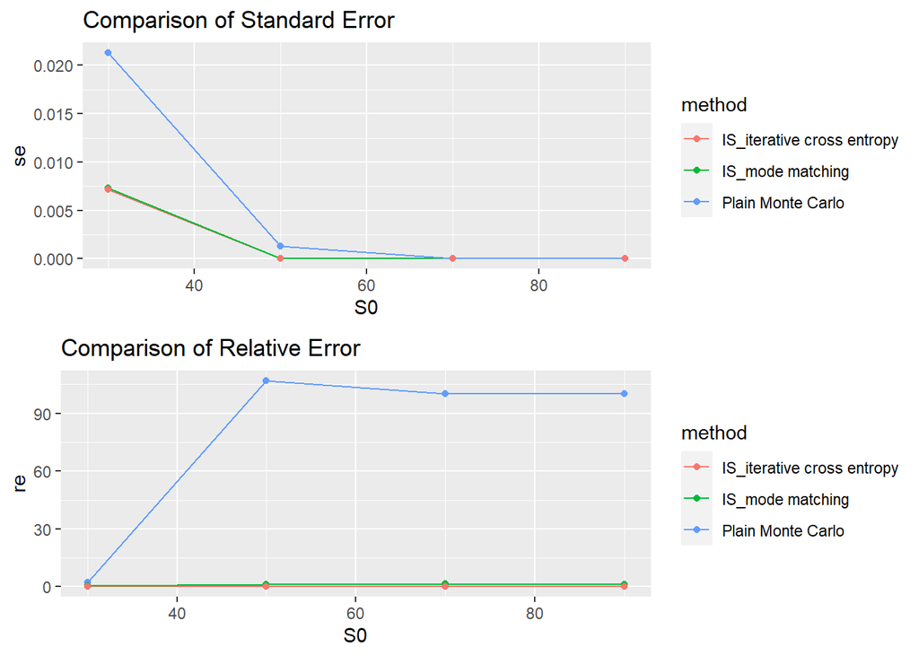

```r
result = data.frame(rep(S0,3))
colnames(result)='S0'
result$method = c(rep('Plain Monte Carlo',4),rep('IS_mode matching',4),rep('IS_iterative cross entropy',4))
result$est = c(est,est1,est2)
result$se = c(se,se1,se2)
result$re = c(re,re1,se2)
library(ggplot2)
library(gridExtra)
p1 = ggplot(result, aes(x=S0, y=se, group=method, color=method))+
  geom_line()+geom_point()+ggtitle("Comparison of Standard Error")
p2 = ggplot(result, aes(x=S0, y=re, group=method, color=method))+
  geom_line()+geom_point()+ggtitle("Comparison of Relative Error")
grid.arrange(p1,p2)
```

## 4 Euler Scheme

### Example 4.2

Method of conditioning

```r
S0 = 50
r0 = 0.04
b = 0.06
a = 1
theta = 0.1
sigma = 0.2
T = 1
rho = 0.8
m = 50
n = 10000
K = 55   # K= 45, 50, 55
t = (0:m)*T/m
```

##### Plain Monte Carlo Methods with Euler Scheme

```r
S = vector()
r = vector()
S[1] = S0
r[1] = r0
H = vector()

sigma_mat = matrix(c(1,rho,rho,1),nrow = 2)
library(MASS)

for (k in 1:n){
  for (i in 1:m){
    data = mvrnorm(1, rep(0, 2), sigma_mat)
    Z = data[1]
    Y = data[2]
    S[i+1] = S[i]+r[i]*S[i]*(t[i+1]-t[i])+sigma*S[i]*sqrt(t[i+1]-t[i])*Z
    r[i+1] = r[i]+a*(b-r[i])*(t[i+1]-t[i])+theta*sqrt(r[i])*sqrt(t[i+1]-t[i])*Y
  }
  R = 0
  for (i in 1:m+1){
    R = R + (t[i]-t[i-1])*r[i-1]
  }

  R = R/T
  H[k] = exp(-R*T)*max(S[m+1]-K,0)
}

est = mean(H)
est
```

```
## [1] 3.141854
```

```r
se = sqrt(var(H)/n)
se
```

```
## [1] 0.06036659
```

##### Euler scheme and method of conditioning

```r
r = vector()
H = vector()
set.seed(29)
for (k in 1:n){
  r[1] = r0
  L = 0
  for (i in 1:m){
    Y = rnorm(1)
    r[i+1] = r[i] + a*(b-r[i])*(t[i+1]-t[i]) +theta*sqrt(r[i])*sqrt(t[i+1]-t[i])*Y
    L = L+sqrt(t[i+1]-t[i])*Y
  }
  Bt = L
  R = 0
  for (i in 1:m+1){
    R = R + (t[i]-t[i-1])*r[i-1]
  }
  R = R/T
  X0 = S0*exp(rho*sigma*Bt-rho^2*sigma^2*T/2)
  Z = rnorm(1)
  Z = rnorm(100)

  v = vector()
  St = X0*exp((R-1/2*sigma^2*(1-rho^2))*T + sigma*sqrt(1-rho^2)*Z)
  for (i in 1:100){
    v[i] = exp(-R*T)*max(St[i]-K,0)
  }
  C = mean(v)

  #not sure about this Qt=Z
  H[k] = C
}

est = mean(H)
est
```

```
## [1] 3.041119
```

```r
est_se = sqrt((sum(H^2)-n*est^2)/(n*(n-1)))
est_se
```

```
## [1] 0.04407457
```

### Example 4.3

Control Variate Method & Euler Scheme

```r
r = 0.05
S0 = 50
K = 50
a = 3
beta = 0.1
theta0 = 0.25
T = 1
big_theta = 0.2
rho = 0.5
m = 50
t = (0:m)*T/m
n = 10000
```

##### Plain Monte Carlo Methods

```r
Y = vector()
theta = vector()

sigma_mat = matrix(c(1,rho,rho,1),nrow = 2)

X = vector()
Y_trace = vector()
for (k in 1:n){
  Y[1] = log(S0)
  theta[1] = theta0
  normal_v = mvrnorm(m, rep(0, 2), sigma_mat)
  Z = normal_v[,1]
  R = normal_v[,2]
  for (i in 1:m){
    Y[i+1] = Y[i]+(r-1/2*theta[i]^2)*(t[i+1]-t[i])+theta[i]*sqrt(t[i+1]-t[i])*Z[i]
    theta[i+1] = theta[i]+a*(big_theta-theta[i])*(t[i+1]-t[i])+beta*sqrt(t[i+1]-t[i])*R[i]
  }
  Y_trace[k] = Y[m+1]
  X[k] = exp(-r*T)*max(exp(Y[m+1])-K,0)
}
#X[1:100]
plain_est = mean(X)
plain_est
```

```
## [1] 5.482284
```

```r
plain_se = sqrt(var(X)/n)
plain_se
```

```
## [1] 0.08515928
```

##### Control Variate Method

```r
sigma = big_theta
Y_hat = vector()
Y_l = vector()
theta = vector()
X = vector()
Q = vector()

set.seed(29)
## Calculate BLS_Call
Z = rnorm(n)

v = vector()
St = S0*exp((r-0.5*sigma^2)*T+sigma*sqrt(T)*Z)
for (i in 1:n){
  v[i] = exp(-r*T)*max(St[i]-K,0)
}
C = mean(v)

for (k in 1:n){
  Y_hat[1] = log(S0)
  Y_l[1] = log(S0)
  theta[1] = theta0
  for (i in 1:m){
    Z = rnorm(1)
    U = rnorm(1)
    R = rho*Z+sqrt(1-rho^2)*U
    Y_hat[i+1] = Y_hat[i]+(r-theta[i]^2/2)*(t[i+1]-t[i])+theta[i]*sqrt(t[i+1]-t[i])*Z
    Y_l[i+1] = Y_l[i]+(r-sigma^2/2)*(t[i+1]-t[i])+sigma*sqrt(t[i+1]-t[i])*Z
    theta[i+1] = theta[i]+a*(big_theta-theta[i])*(t[i+1]-t[i])+beta*sqrt(t[i+1]-t[i])*R

  }
  X[k] = exp(-r*T)*max(exp(Y_hat[m+1])-K,0)
  Q[k] = exp(-r*T)*max(exp(Y_l[m+1])-K,0)-C
}

b_optimal = sum((X-mean(X))*(Q-mean(Q)))/sum((Q-mean(Q))^2)
b_optimal
```

```
## [1] 1.148535
```

```r
H = X-b_optimal*Q

v_est = mean(H)
v_est
```

```
## [1] 5.544239
```

```r
se_est = sqrt((sum(H^2)-n*v_est^2)/(n*(n-1)))
se_est
```

```
## [1] 0.01781896
```

##### Comments

After using Control Variate Method with euler scheme, the standard error is much less than plain euler scheme.

### Example 4.4 Importance Sampling with Euler Scheme

Estimate the price of a put option, where the stock price is a CEV process under risk-neutral probability method.

```r
S0=50
r=0.05
sigma=0.2
T=1
m=50
n=10000
N=2000
K = c(50,52,55)
t = (0:m)*T/m
```

##### Plain Monte Carlo method

```r
X = vector()
XT = vector()
h = vector()
plain_est = vector()
plain_se = vector()
set.seed(29)
for (j in 1:3){
  for (k in 1:n){
    X[1] = S0
    for (i in 1:m){
      Z = rnorm(1)
      X[i+1] = max(0, X[i]+sigma*exp(-r*1/2*t[i])*sqrt(X[i])*sqrt(t[i+1]-t[i])*Z)
    }
    XT[k] = X[m+1]
    h[k] = max(exp(-r*T)*K[j]-XT[k],0)
  }

  plain_est[j] = mean(h)
  plain_se[j] = sqrt(var(h)/n)
}
plain_est
```

```
## [1] 0.01916289 0.33223573 2.35090900
```

```r
plain_se
```

```
## [1] 0.001292019 0.006183971 0.013455302
```

##### Basic Cross-entropy method

```r
IS_est = vector()
IS_se =vector()
for (j in 1:3){
  Y = matrix(0,nrow = N,ncol = m)
  set.seed(29)
  theta = vector()
  for (k in 1:N){
    for(i in 1:m){
      Y[k,i] = rnorm(1)
    }
  }
  X = vector()
  h = vector()
  for (k in 1:N){
    X[1]= S0
    for (i in 1:m){
      X[i+1] = max(0, X[i]+sigma*exp(-r*1/2*t[i])*sqrt(X[i])*sqrt(t[i+1]-t[i])*Y[k,i])
      }
    h[k] = max(exp(-r*T)*K[j]-X[m+1],0)
  }

  denom = rep(0,m)
  for (i in 1:N){
    denom = denom+h[i]*Y[i,]
  }
  theta = denom/sum(h)
  theta

  H = vector()
  for (k in 1:n){
    Z = vector()
    for (i in 1:m){
      Z[i] = rnorm(1, theta[i],1)
      X[i+1] = max(0, X[i]+sigma*exp(-r*(1/2)*t[i])*sqrt(X[i])*sqrt(t[i+1]-t[i])*Z[i])
    }
    H[k] = max(exp(-r*T)*K[j]-X[m+1],0)*exp(-sum(theta*Z)+0.5*sum(theta^2))
  }


  IS_est[j] = mean(H)
  IS_se[j] = sqrt((sum(H^2)-n*IS_est[j]^2)/(n*(n-1)))
}
IS_est
```

```
## [1] 0.02106187 0.32673718 2.34904576
```

```r
IS_se
```

```
## [1] 0.0005023205 0.0022395263 0.0063313823
```

##### Comparison of the result

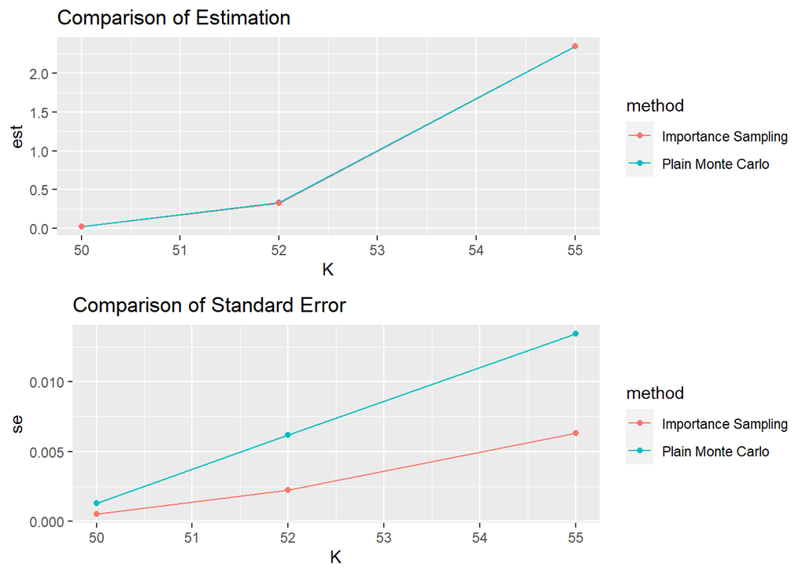

```r
result = data.frame(rep(K,2))
colnames(result)='K'
result$method = c(rep('Plain Monte Carlo',3),rep('Importance Sampling',3))
result$est = c(plain_est,IS_est)
result$se = c(plain_se, IS_se)
library(ggplot2)
library(gridExtra)
p1 = ggplot(result, aes(x=K, y=est, group=method, color=method))+
  geom_line()+geom_point()+ggtitle("Comparison of Estimation")
p2 = ggplot(result, aes(x=K, y=se, group=method, color=method))+
  geom_line()+geom_point()+ggtitle("Comparison of Standard Error")
grid.arrange(p1,p2)
```

### Exercise 4.A Euler Scheme to approximate XT, suppose X is a geometric Brownian motion with drift r and volatility σ

```r
r = 0.12
sigma = 0.2
T = 1
X0 = 50
n = 10000
m_vec = c(5,10,20,40,60,80,100)

error = vector()
h_vec = vector()
for (k in 1:length(m_vec)){
  m = m_vec[k]
  m
  t = vector()
  h_vec[k] = T/m
  t = (0:m)*h_vec[k]
  set.seed(29)

  final_est = vector()
  final_real = vector()
  for (j in 1:n){
    X_est = vector()
    X_est[1] = X0
    X_real = vector()
    X_real[1] = X0
    for (i in 1:m+1){
      Z = rnorm(1)
      X_est[i] = X_est[i-1]+r*X_est[i-1]*h_vec[k]+sigma*X_est[i-1]*sqrt(h_vec[k])*Z
      X_real[i] =X_real[i-1]*exp((r-0.5*sigma^2)*h_vec[k]+sigma*sqrt(h_vec[k])*Z)
    }
    final_est[j] = X_est[m+1]
    final_real[j] = X_real[m+1]
  }
  error[k] = mean(abs(final_est-final_real))
}
error
```

```
## [1] 0.5600780 0.4014462 0.2839540 0.2010351 0.1623401 0.1404637 0.1252831
```

##### Visualize the error

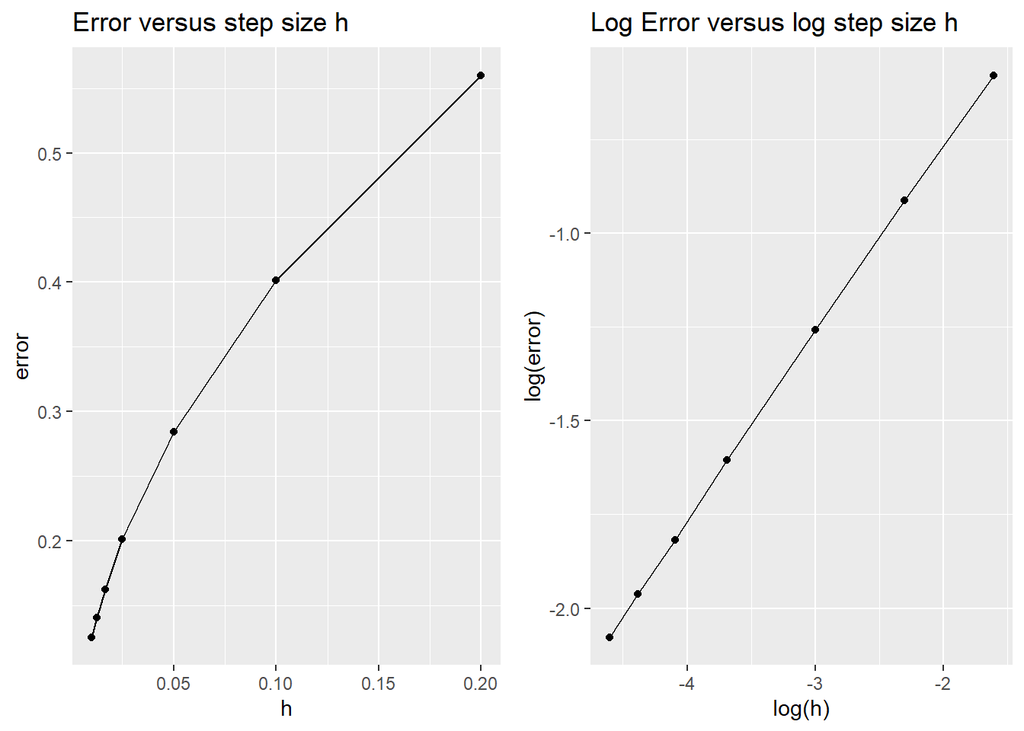

```r
result = data.frame(h_vec)
colnames(result)='h'
result$error = error
library(ggplot2)
p1 = ggplot(result, aes(x=h, y=error))+
  geom_line()+geom_point()+ggtitle("Error versus step size h")
p2 = ggplot(result, aes(x=log(h), y=log(error)))+
  geom_line()+geom_point()+ggtitle("Log Error versus log step size h")
library(gridExtra)
grid.arrange(p1,p2, ncol=2)
```

### Exercise 4.B Importance Sampling and cross-entropy method for estimating the call option with the underlying stock following a CEV process.

```r
S0 = 50
r = 0.05
sigma = 0.2
T = 1
m = 50
n = 10000
N = 2000
t = (0:m)*T/m
gamma = 0.5
K = 50
```

##### Plain Monte Carlo Methods

```r
X = vector()
XT = vector()
h = vector()
set.seed(35)
for (k in 1:n){
  X[1] = S0
  for (i in 1:m){
    Z = rnorm(1)
    X[i+1] = max(0, X[i]+sigma*exp(-r*(1-gamma)*t[i])*X[i]^gamma*sqrt(t[i+1]-t[i])*Z)
  }
  XT[k] = X[m+1]
  h[k] = max(XT[k]-exp(-r*T)*K,0)
}

plain_est = mean(h)
plain_est
```

```
## [1] 2.46258
```

```r
plain_se = sqrt(var(h)/n)
plain_se
```

```
## [1] 0.01361585
```

##### Importance Sampling with Basic Cross-entropy method

```r
Y = matrix(0,nrow = N,ncol = m)
set.seed(35)
theta = vector()
for (k in 1:N){
  for(i in 1:m){
    Y[k,i] = rnorm(1)
  }
}
X = vector()
h = vector()
for (k in 1:N){
  X[1]= S0
  for (i in 1:m){
    X[i+1] = max(0, X[i]+sigma*exp(-r*(1-gamma)*t[i])*X[i]^gamma*sqrt(t[i+1]-t[i])*Y[k,i])
    }
  h[k] = max(X[m+1]-exp(-r*T)*K,0)
}

denom = rep(0,m)
for (i in 1:N){
  denom = denom+h[i]*Y[i,]
}
theta = denom/sum(h)
#theta

H = vector()
for (k in 1:n){
  Z = vector()
  for (i in 1:m){
    Z[i] = rnorm(1, theta[i],1)
    X[i+1] = max(0, X[i]+sigma*exp(-r*(1-gamma)*t[i])*X[i]^gamma*sqrt(t[i+1]-t[i])*Z[i])
  }
  H[k] = max(X[m+1]-exp(-r*T)*K,0)*exp(-sum(theta*Z)+0.5*sum(theta^2))
}


IS_est = mean(H)
IS_est
```

```
## [1] 2.451909
```

```r
IS_se = sqrt((sum(H^2)-n*IS_est^2)/(n*(n-1)))
IS_se
```

```
## [1] 0.006633368
```

### Exercise 4.C

A discretization scheme without discretization error to estimate the option price of a lookback call option.

```r
S0 = 20
r = 0.05
T = 1
a = 0.4
b = 0.3
m = 20    # 5,10,20
t = (0:m)*T/m

n = 100000
Y = vector()
H = vector()
sigma2 = vector()
set.seed(29)
for (k in 1:n){
  Y[1] = log(S0)
  S[1] = S0
  for (i in 1:m){
    Z = rnorm(1)
    sigma2[i] = a^2*(t[i+1]-t[i])+b^2*T/(2*pi)*(cos(2*pi*t[i]/T)-cos(2*pi*t[i+1]/T))
    Y[i+1] = Y[i]+r*(t[i+1]-t[i])-sigma2[i]/2+sqrt(sigma2[i])*Z
    S[i+1] = exp(Y[i+1])
  }
  H[k] = exp(-r*T)*(S[m+1]-min(S))
}

est_v = mean(H)
est_v
```

```
## [1] 5.308904
```

```r
est_se = sqrt((sum(H^2)-n*est_v^2)/(n*(n-1)))
est_se
```

```
## [1] 0.01958486
```